### (a) Which of the predictors are quantitative, and which are qualitative?

```r
> str(Auto)
```

```
'data.frame':   392 obs. of  9 variables:
 $ mpg         : num  18 15 18 16 17 15 14 14 14 15 ...
 $ cylinders   : num  8 8 8 8 8 8 8 8 8 8 ...
 $ displacement: num  307 350 318 304 302 429 454 440 455 390 ...
 $ horsepower  : num  130 165 150 150 140 198 220 215 225 190 ...
 $ weight      : num  3504 3693 3436 3433 3449 ...
 $ acceleration: num  12 11.5 11 12 10.5 10 9 8.5 10 8.5 ...
 $ year        : num  70 70 70 70 70 70 70 70 70 70 ...
 $ origin      : num  1 1 1 1 1 1 1 1 1 1 ...
 $ name        : Factor w/ 304 levels "amc ambassador brougham",..: 49 36 231 14 161 141 54 223 241 2 ...
```

```r
> Auto$year <- as.factor(Auto$year)
> Auto$origin <- as.factor(Auto$origin)
```

### (b) What is the range of each quantitative predictor? You can answer this using the range() function.

```r
> column_names <- which(names(Auto) %in% c("year","name", "origin"))
> column_names
```

```
[1] 7 8 9
```

```r
> sapply(Auto[, -column_names], range)
```

```
      mpg cylinders displacement horsepower weight acceleration
[1,]  9.0         3           68         46   1613          8.0
[2,] 46.6         8          455        230   5140         24.8
```

### (c) What is the mean and standard deviation of each quantitative predictor?

```r
> sapply(Auto[, -column_names], mean)
```

```
         mpg    cylinders displacement   horsepower       weight acceleration
   23.445918     5.471939   194.411990   104.469388  2977.584184    15.541327
```

```r
> sapply(Auto[, -column_names], sd)
```

```
         mpg    cylinders displacement   horsepower       weight acceleration
    7.805007     1.705783   104.644004    38.491160   849.402560     2.758864
```

### (d) Now remove the 10th through 85th observations. What is the range, mean, and standard deviation of each predictor in the subset of the data that remains?

```r
> rangedata <- Auto[-seq(10, 85), -column_names]
> sapply(rangedata,range)
```

```
      mpg cylinders displacement horsepower weight acceleration
[1,] 11.0         3           68         46   1649          8.5
[2,] 46.6         8          455        230   4997         24.8
```

```r
> sapply(rangedata[-ncol(rangedata)],mean)
```

```
         mpg    cylinders displacement   horsepower       weight
   24.404430     5.373418   187.240506   100.721519  2935.971519
```

```r
> sapply(rangedata[-ncol(rangedata)],sd)
```

```
         mpg    cylinders displacement   horsepower       weight
    7.867283     1.654179    99.678367    35.708853   811.300208
```

### (e) Using the full data set, investigate the predictors graphically, using scatterplots or other tools of your choice. Create some plots highlighting the relationships among the predictors. Comment on your findings.

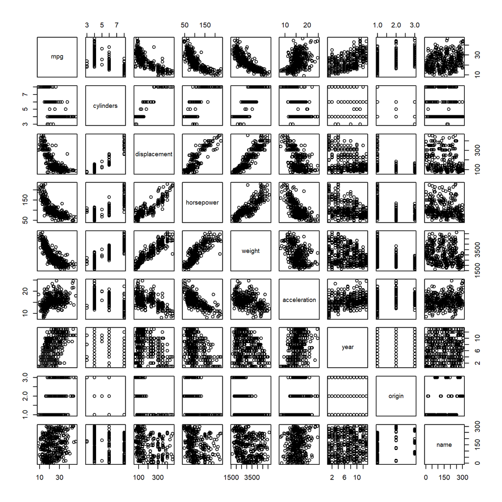

```r
> plot(Auto)
```

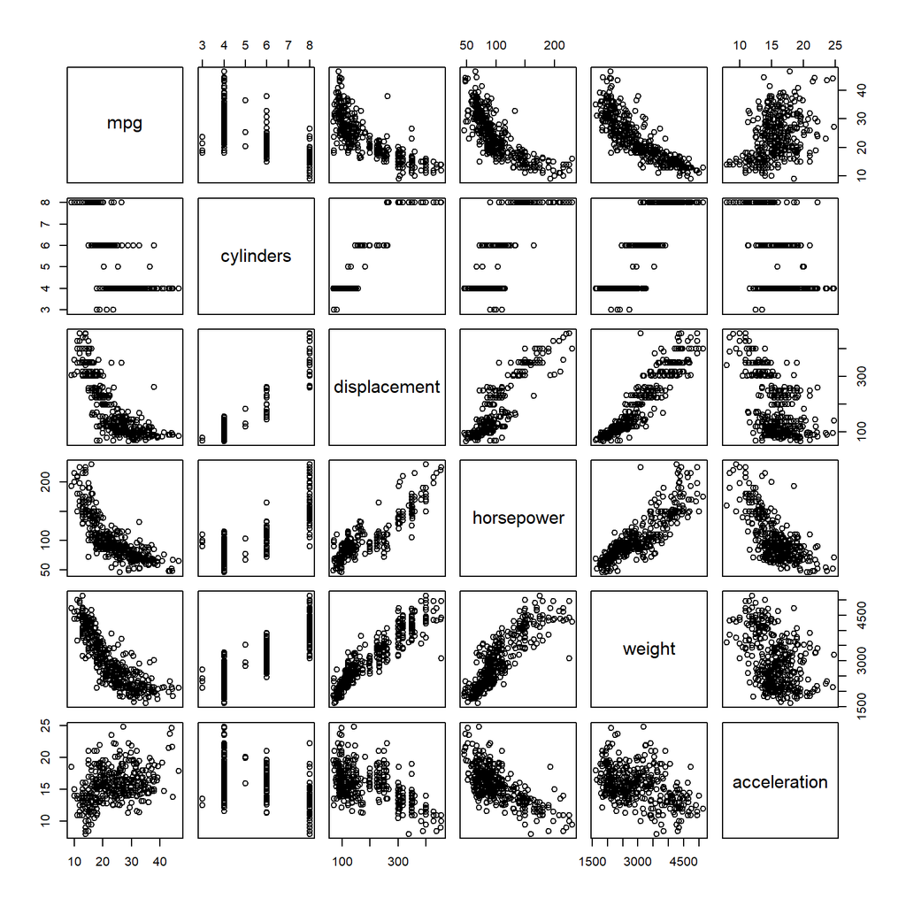

```r
> pairs(Auto[, -column_names])
```

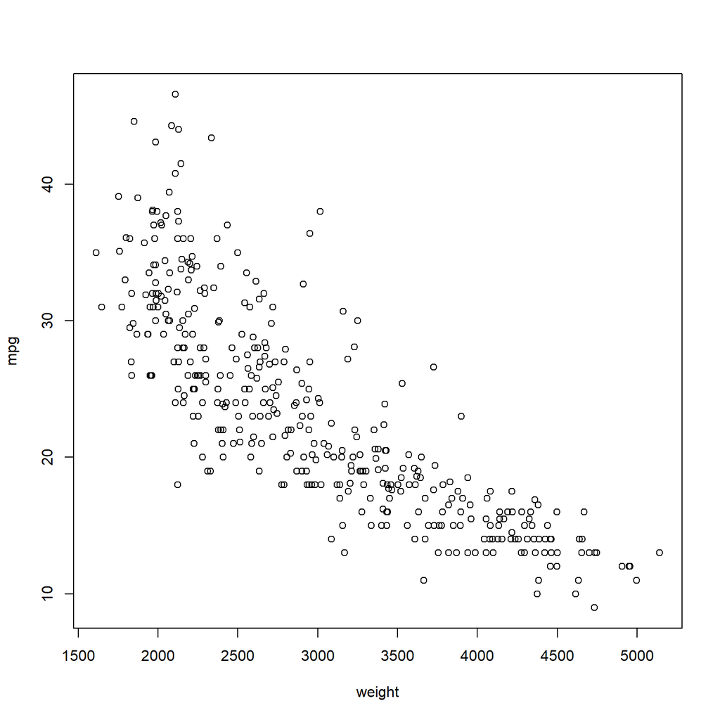

```r
> plot(mpg ~ weight, data = Auto)
```

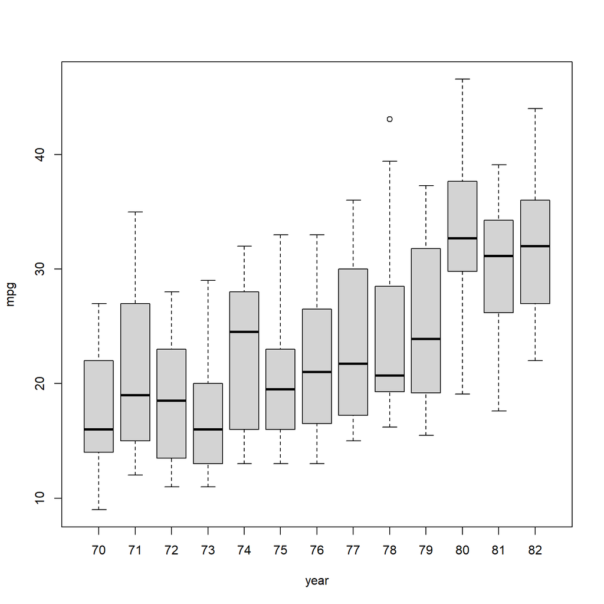

```r
> plot(mpg ~ year, data = Auto)
```

### (f) Suppose that we wish to predict gas mileage (mpg) on the basis of the other variables. Do your plots suggest that any of the other variables might be useful in predicting mpg? Justify your answer.

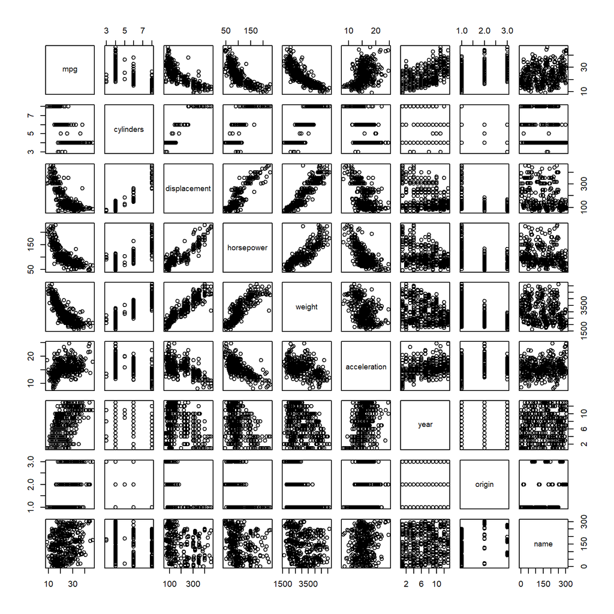

```r
> pairs(Auto)
```

All the predictors have some connection to mpg. However, the factor named “name” doesn’t have enough data points for accurate predictions and could lead to making incorrect assumptions. It’s better not to use this factor to avoid bad the results.